# Risk Factor Analysis

## Outcome Variable

**Outcome Variable:** ever_co

## Predictor Variables

**Intervention Variable:** nhh

**Adjustment Set:**

- arm
- W_mage
- meducyrs
- feducyrs
- W_mhtcm
- W_mwtkg
- W_mbmi
- W_nrooms
- impfloor
- impsan
- safeh20
- delta_W_mage
- delta_meducyrs
- delta_feducyrs
- delta_W_mhtcm
- delta_W_mwtkg
- delta_W_mbmi
- delta_W_nrooms
- delta_impfloor
- delta_impsan
- delta_safeh20

## Stratifying Variables

The analysis was stratified on these variable(s):

- agecat
- studyid
- country

## Data Summary

| agecat | studyid | country | nhh | ever_co | n_cell | n |
| --- | --- | --- | --- | --- | --- | --- |
| 0-24 months | ki1000108-IRC | INDIA | 3 or less | 0 | 51 | 410 |
| 0-24 months | ki1000108-IRC | INDIA | 3 or less | 1 | 7 | 410 |
| 0-24 months | ki1000108-IRC | INDIA | 4-5 | 0 | 129 | 410 |
| 0-24 months | ki1000108-IRC | INDIA | 4-5 | 1 | 29 | 410 |
| 0-24 months | ki1000108-IRC | INDIA | 6-7 | 0 | 89 | 410 |
| 0-24 months | ki1000108-IRC | INDIA | 6-7 | 1 | 18 | 410 |
| 0-24 months | ki1000108-IRC | INDIA | 8+ | 0 | 65 | 410 |
| 0-24 months | ki1000108-IRC | INDIA | 8+ | 1 | 22 | 410 |
| 0-24 months | ki1000304b-SAS-FoodSuppl | INDIA | 3 or less | 0 | 28 | 418 |
| 0-24 months | ki1000304b-SAS-FoodSuppl | INDIA | 3 or less | 1 | 10 | 418 |
| 0-24 months | ki1000304b-SAS-FoodSuppl | INDIA | 4-5 | 0 | 113 | 418 |
| 0-24 months | ki1000304b-SAS-FoodSuppl | INDIA | 4-5 | 1 | 70 | 418 |
| 0-24 months | ki1000304b-SAS-FoodSuppl | INDIA | 6-7 | 0 | 79 | 418 |
| 0-24 months | ki1000304b-SAS-FoodSuppl | INDIA | 6-7 | 1 | 48 | 418 |
| 0-24 months | ki1000304b-SAS-FoodSuppl | INDIA | 8+ | 0 | 43 | 418 |
| 0-24 months | ki1000304b-SAS-FoodSuppl | INDIA | 8+ | 1 | 27 | 418 |
| 0-24 months | ki1017093-NIH-Birth | BANGLADESH | 3 or less | 0 | 93 | 624 |
| 0-24 months | ki1017093-NIH-Birth | BANGLADESH | 3 or less | 1 | 22 | 624 |
| 0-24 months | ki1017093-NIH-Birth | BANGLADESH | 4-5 | 0 | 196 | 624 |
| 0-24 months | ki1017093-NIH-Birth | BANGLADESH | 4-5 | 1 | 67 | 624 |
| 0-24 months | ki1017093-NIH-Birth | BANGLADESH | 6-7 | 0 | 114 | 624 |
| 0-24 months | ki1017093-NIH-Birth | BANGLADESH | 6-7 | 1 | 27 | 624 |
| 0-24 months | ki1017093-NIH-Birth | BANGLADESH | 8+ | 0 | 84 | 624 |
| 0-24 months | ki1017093-NIH-Birth | BANGLADESH | 8+ | 1 | 21 | 624 |
| 0-24 months | ki1017093b-PROVIDE | BANGLADESH | 3 or less | 0 | 128 | 700 |
| 0-24 months | ki1017093b-PROVIDE | BANGLADESH | 3 or less | 1 | 12 | 700 |
| 0-24 months | ki1017093b-PROVIDE | BANGLADESH | 4-5 | 0 | 281 | 700 |
| 0-24 months | ki1017093b-PROVIDE | BANGLADESH | 4-5 | 1 | 41 | 700 |
| 0-24 months | ki1017093b-PROVIDE | BANGLADESH | 6-7 | 0 | 127 | 700 |
| 0-24 months | ki1017093b-PROVIDE | BANGLADESH | 6-7 | 1 | 24 | 700 |

[output cut: 114 more lines]

The following strata were considered:

- agecat: 0-24 months, studyid: ki1000108-IRC, country: INDIA
- agecat: 0-24 months, studyid: ki1000304b-SAS-FoodSuppl, country: INDIA
- agecat: 0-24 months, studyid: ki1017093-NIH-Birth, country: BANGLADESH
- agecat: 0-24 months, studyid: ki1017093b-PROVIDE, country: BANGLADESH
- agecat: 0-24 months, studyid: ki1017093c-NIH-Crypto, country: BANGLADESH
- agecat: 0-24 months, studyid: ki1148112-LCNI-5, country: MALAWI
- agecat: 0-6 months, studyid: ki1000108-IRC, country: INDIA
- agecat: 0-6 months, studyid: ki1000304b-SAS-FoodSuppl, country: INDIA
- agecat: 0-6 months, studyid: ki1017093-NIH-Birth, country: BANGLADESH
- agecat: 0-6 months, studyid: ki1017093b-PROVIDE, country: BANGLADESH
- agecat: 0-6 months, studyid: ki1017093c-NIH-Crypto, country: BANGLADESH
- agecat: 0-6 months, studyid: ki1148112-LCNI-5, country: MALAWI
- agecat: 6-24 months, studyid: ki1000108-IRC, country: INDIA
- agecat: 6-24 months, studyid: ki1000304b-SAS-FoodSuppl, country: INDIA
- agecat: 6-24 months, studyid: ki1017093-NIH-Birth, country: BANGLADESH
- agecat: 6-24 months, studyid: ki1017093b-PROVIDE, country: BANGLADESH
- agecat: 6-24 months, studyid: ki1017093c-NIH-Crypto, country: BANGLADESH
- agecat: 6-24 months, studyid: ki1148112-LCNI-5, country: MALAWI

### Dropped Strata

Some strata were dropped due to rare outcomes:

- agecat: 0-6 months, studyid: ki1000108-IRC, country: INDIA
- agecat: 0-6 months, studyid: ki1000304b-SAS-FoodSuppl, country: INDIA
- agecat: 0-6 months, studyid: ki1017093b-PROVIDE, country: BANGLADESH
- agecat: 0-6 months, studyid: ki1017093c-NIH-Crypto, country: BANGLADESH
- agecat: 0-6 months, studyid: ki1148112-LCNI-5, country: MALAWI

## Methods Detail

We’re interested in the causal parameters $E[Y_a]$ for all values of $a \in \mathcal{A}$. These parameters represent the mean outcome if, possibly contrary to fact, we intervened to set all units to have $A=a$. Under the randomization and positivity assumptions, these are identified by the statistical parameters $\psi_a=E_W[E_{Y|A,W}(Y|A=a,W)]$. In addition, we’re interested in the mean of $Y$, $E[Y]$ under no intervention (the observed mean). We will estimate these parameters by using SuperLearner to fit the relevant likelihood factors – $E_{Y|A,W}(Y|A=a,W)$ and $p(A=a|W)$, and then updating our likelihood fit using a joint TMLE.

For unadjusted analyses ($W=\{\}$), initial likelihoods were estimated using Lrnr_glm to estimate the simple $E(Y|A)$ and Lrnr_mean to estimate $p(A)$. For adjusted analyses, a small library containing Lrnr_glmnet, Lrnr_xgboost, and Lrnr_mean was used.

Having estimated these parameters, we will then use the delta method to estimate relative risks and attributable risks relative to a prespecified baseline level of $A$.

# Results Detail

## Results Plots

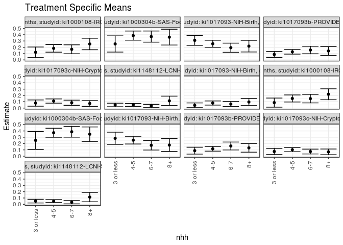

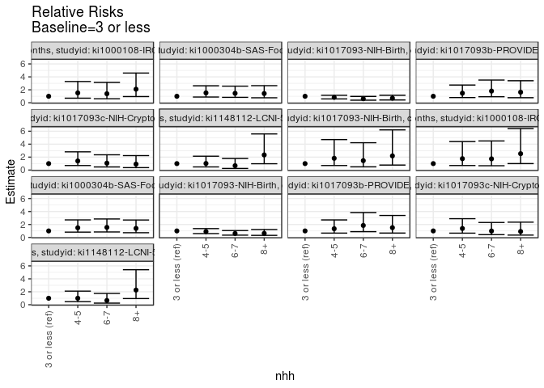

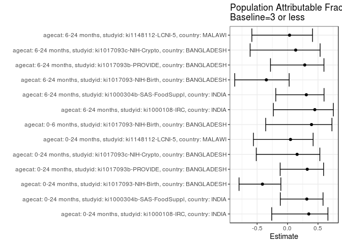

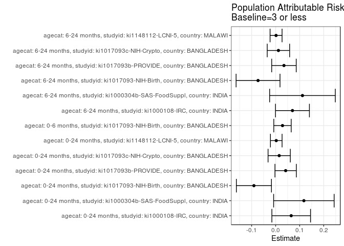

## Results Table

### Parameter: TSM

| agecat | studyid | country | intervention_level | baseline_level | estimate | ci_lower | ci_upper |
| --- | --- | --- | --- | --- | --- | --- | --- |
| 0-24 months | ki1000108-IRC | INDIA | 3 or less | NA | 0.1206897 | 0.0367494 | 0.2046299 |
| 0-24 months | ki1000108-IRC | INDIA | 4-5 | NA | 0.1835443 | 0.1231096 | 0.2439790 |
| 0-24 months | ki1000108-IRC | INDIA | 6-7 | NA | 0.1682243 | 0.0972610 | 0.2391876 |
| 0-24 months | ki1000108-IRC | INDIA | 8+ | NA | 0.2528736 | 0.1614270 | 0.3443202 |
| 0-24 months | ki1000304b-SAS-FoodSuppl | INDIA | 3 or less | NA | 0.2533237 | 0.1244647 | 0.3821827 |
| 0-24 months | ki1000304b-SAS-FoodSuppl | INDIA | 4-5 | NA | 0.3858332 | 0.3132145 | 0.4584519 |
| 0-24 months | ki1000304b-SAS-FoodSuppl | INDIA | 6-7 | NA | 0.3702742 | 0.2817171 | 0.4588313 |
| 0-24 months | ki1000304b-SAS-FoodSuppl | INDIA | 8+ | NA | 0.3613887 | 0.2360635 | 0.4867138 |
| 0-24 months | ki1017093-NIH-Birth | BANGLADESH | 3 or less | NA | 0.3100439 | 0.2312508 | 0.3888370 |
| 0-24 months | ki1017093-NIH-Birth | BANGLADESH | 4-5 | NA | 0.2563095 | 0.2003656 | 0.3122534 |
| 0-24 months | ki1017093-NIH-Birth | BANGLADESH | 6-7 | NA | 0.1935685 | 0.1211039 | 0.2660332 |
| 0-24 months | ki1017093-NIH-Birth | BANGLADESH | 8+ | NA | 0.2185408 | 0.1258574 | 0.3112242 |
| 0-24 months | ki1017093b-PROVIDE | BANGLADESH | 3 or less | NA | 0.0869447 | 0.0395379 | 0.1343516 |
| 0-24 months | ki1017093b-PROVIDE | BANGLADESH | 4-5 | NA | 0.1285875 | 0.0919377 | 0.1652373 |
| 0-24 months | ki1017093b-PROVIDE | BANGLADESH | 6-7 | NA | 0.1568970 | 0.0971689 | 0.2166251 |
| 0-24 months | ki1017093b-PROVIDE | BANGLADESH | 8+ | NA | 0.1417374 | 0.0717023 | 0.2117725 |
| 0-24 months | ki1017093c-NIH-Crypto | BANGLADESH | 3 or less | NA | 0.0789474 | 0.0294145 | 0.1284802 |
| 0-24 months | ki1017093c-NIH-Crypto | BANGLADESH | 4-5 | NA | 0.1111111 | 0.0777820 | 0.1444403 |
| 0-24 months | ki1017093c-NIH-Crypto | BANGLADESH | 6-7 | NA | 0.0842697 | 0.0434336 | 0.1251058 |
| 0-24 months | ki1017093c-NIH-Crypto | BANGLADESH | 8+ | NA | 0.0725806 | 0.0268853 | 0.1182760 |
| 0-24 months | ki1148112-LCNI-5 | MALAWI | 3 or less | NA | 0.0488889 | 0.0206957 | 0.0770820 |
| 0-24 months | ki1148112-LCNI-5 | MALAWI | 4-5 | NA | 0.0500000 | 0.0268196 | 0.0731804 |
| 0-24 months | ki1148112-LCNI-5 | MALAWI | 6-7 | NA | 0.0329670 | 0.0070110 | 0.0589231 |
| 0-24 months | ki1148112-LCNI-5 | MALAWI | 8+ | NA | 0.1142857 | 0.0397082 | 0.1888632 |
| 0-6 months | ki1017093-NIH-Birth | BANGLADESH | 3 or less | NA | 0.0438597 | 0.0062379 | 0.0814814 |
| 0-6 months | ki1017093-NIH-Birth | BANGLADESH | 4-5 | NA | 0.0798479 | 0.0470625 | 0.1126334 |
| 0-6 months | ki1017093-NIH-Birth | BANGLADESH | 6-7 | NA | 0.0638298 | 0.0234488 | 0.1042108 |
| 0-6 months | ki1017093-NIH-Birth | BANGLADESH | 8+ | NA | 0.0961538 | 0.0394501 | 0.1528575 |
| 6-24 months | ki1000108-IRC | INDIA | 3 or less | NA | 0.0862069 | 0.0138868 | 0.1585271 |
| 6-24 months | ki1000108-IRC | INDIA | 4-5 | NA | 0.1518987 | 0.0958648 | 0.2079326 |
| 6-24 months | ki1000108-IRC | INDIA | 6-7 | NA | 0.1495327 | 0.0818803 | 0.2171851 |
| 6-24 months | ki1000108-IRC | INDIA | 8+ | NA | 0.2183908 | 0.1314686 | 0.3053130 |
| 6-24 months | ki1000304b-SAS-FoodSuppl | INDIA | 3 or less | NA | 0.2500000 | 0.1083751 | 0.3916249 |
| 6-24 months | ki1000304b-SAS-FoodSuppl | INDIA | 4-5 | NA | 0.3714286 | 0.2997505 | 0.4431066 |
| 6-24 months | ki1000304b-SAS-FoodSuppl | INDIA | 6-7 | NA | 0.3870968 | 0.3012577 | 0.4729359 |
| 6-24 months | ki1000304b-SAS-FoodSuppl | INDIA | 8+ | NA | 0.3484848 | 0.2333856 | 0.4635841 |
| 6-24 months | ki1017093-NIH-Birth | BANGLADESH | 3 or less | NA | 0.2835748 | 0.1866859 | 0.3804636 |
| 6-24 months | ki1017093-NIH-Birth | BANGLADESH | 4-5 | NA | 0.2537764 | 0.1929439 | 0.3146089 |
| 6-24 months | ki1017093-NIH-Birth | BANGLADESH | 6-7 | NA | 0.1724572 | 0.0978086 | 0.2471059 |
| 6-24 months | ki1017093-NIH-Birth | BANGLADESH | 8+ | NA | 0.1762131 | 0.0737546 | 0.2786717 |
| 6-24 months | ki1017093b-PROVIDE | BANGLADESH | 3 or less | NA | 0.0876130 | 0.0329527 | 0.1422734 |
| 6-24 months | ki1017093b-PROVIDE | BANGLADESH | 4-5 | NA | 0.1172673 | 0.0801520 | 0.1543827 |
| 6-24 months | ki1017093b-PROVIDE | BANGLADESH | 6-7 | NA | 0.1615203 | 0.0988659 | 0.2241748 |
| 6-24 months | ki1017093b-PROVIDE | BANGLADESH | 8+ | NA | 0.1319975 | 0.0638715 | 0.2001235 |
| 6-24 months | ki1017093c-NIH-Crypto | BANGLADESH | 3 or less | NA | 0.0747664 | 0.0248971 | 0.1246356 |
| 6-24 months | ki1017093c-NIH-Crypto | BANGLADESH | 4-5 | NA | 0.1030303 | 0.0702087 | 0.1358519 |
| 6-24 months | ki1017093c-NIH-Crypto | BANGLADESH | 6-7 | NA | 0.0738636 | 0.0351965 | 0.1125308 |
| 6-24 months | ki1017093c-NIH-Crypto | BANGLADESH | 8+ | NA | 0.0683761 | 0.0226119 | 0.1141402 |
| 6-24 months | ki1148112-LCNI-5 | MALAWI | 3 or less | NA | 0.0504587 | 0.0213840 | 0.0795334 |
| 6-24 months | ki1148112-LCNI-5 | MALAWI | 4-5 | NA | 0.0505952 | 0.0271460 | 0.0740445 |
| 6-24 months | ki1148112-LCNI-5 | MALAWI | 6-7 | NA | 0.0331492 | 0.0070519 | 0.0592464 |
| 6-24 months | ki1148112-LCNI-5 | MALAWI | 8+ | NA | 0.1142857 | 0.0397075 | 0.1888639 |

### Parameter: E(Y)

| agecat | studyid | country | intervention_level | baseline_level | estimate | ci_lower | ci_upper |
| --- | --- | --- | --- | --- | --- | --- | --- |
| 0-24 months | ki1000108-IRC | INDIA | NA | NA | 0.1853659 | 0.1477057 | 0.2230261 |
| 0-24 months | ki1000304b-SAS-FoodSuppl | INDIA | NA | NA | 0.3708134 | 0.3244530 | 0.4171738 |
| 0-24 months | ki1017093-NIH-Birth | BANGLADESH | NA | NA | 0.2195513 | 0.1870467 | 0.2520558 |
| 0-24 months | ki1017093b-PROVIDE | BANGLADESH | NA | NA | 0.1285714 | 0.1037574 | 0.1533855 |
| 0-24 months | ki1017093c-NIH-Crypto | BANGLADESH | NA | NA | 0.0936675 | 0.0729118 | 0.1144233 |
| 0-24 months | ki1148112-LCNI-5 | MALAWI | NA | NA | 0.0514076 | 0.0362561 | 0.0665591 |
| 0-6 months | ki1017093-NIH-Birth | BANGLADESH | NA | NA | 0.0723473 | 0.0519719 | 0.0927227 |
| 6-24 months | ki1000108-IRC | INDIA | NA | NA | 0.1560976 | 0.1209228 | 0.1912723 |
| 6-24 months | ki1000304b-SAS-FoodSuppl | INDIA | NA | NA | 0.3615960 | 0.3145115 | 0.4086805 |
| 6-24 months | ki1017093-NIH-Birth | BANGLADESH | NA | NA | 0.2103321 | 0.1759902 | 0.2446740 |
| 6-24 months | ki1017093b-PROVIDE | BANGLADESH | NA | NA | 0.1221498 | 0.0962275 | 0.1480722 |
| 6-24 months | ki1017093c-NIH-Crypto | BANGLADESH | NA | NA | 0.0863014 | 0.0659171 | 0.1066856 |
| 6-24 months | ki1148112-LCNI-5 | MALAWI | NA | NA | 0.0521739 | 0.0368026 | 0.0675452 |

### Parameter: RR

| agecat | studyid | country | intervention_level | baseline_level | estimate | ci_lower | ci_upper |
| --- | --- | --- | --- | --- | --- | --- | --- |
| 0-24 months | ki1000108-IRC | INDIA | 3 or less | 3 or less | 1.0000000 | 1.0000000 | 1.0000000 |
| 0-24 months | ki1000108-IRC | INDIA | 4-5 | 3 or less | 1.5207957 | 0.7044945 | 3.2829487 |
| 0-24 months | ki1000108-IRC | INDIA | 6-7 | 3 or less | 1.3938585 | 0.6179437 | 3.1440430 |
| 0-24 months | ki1000108-IRC | INDIA | 8+ | 3 or less | 2.0952381 | 0.9567285 | 4.5885773 |
| 0-24 months | ki1000304b-SAS-FoodSuppl | INDIA | 3 or less | 3 or less | 1.0000000 | 1.0000000 | 1.0000000 |
| 0-24 months | ki1000304b-SAS-FoodSuppl | INDIA | 4-5 | 3 or less | 1.5230839 | 0.8852389 | 2.6205180 |
| 0-24 months | ki1000304b-SAS-FoodSuppl | INDIA | 6-7 | 3 or less | 1.4616642 | 0.8330388 | 2.5646610 |
| 0-24 months | ki1000304b-SAS-FoodSuppl | INDIA | 8+ | 3 or less | 1.4265886 | 0.7700597 | 2.6428537 |
| 0-24 months | ki1017093-NIH-Birth | BANGLADESH | 3 or less | 3 or less | 1.0000000 | 1.0000000 | 1.0000000 |
| 0-24 months | ki1017093-NIH-Birth | BANGLADESH | 4-5 | 3 or less | 0.8266877 | 0.5927070 | 1.1530363 |
| 0-24 months | ki1017093-NIH-Birth | BANGLADESH | 6-7 | 3 or less | 0.6243262 | 0.3975945 | 0.9803535 |
| 0-24 months | ki1017093-NIH-Birth | BANGLADESH | 8+ | 3 or less | 0.7048705 | 0.4303348 | 1.1545485 |
| 0-24 months | ki1017093b-PROVIDE | BANGLADESH | 3 or less | 3 or less | 1.0000000 | 1.0000000 | 1.0000000 |
| 0-24 months | ki1017093b-PROVIDE | BANGLADESH | 4-5 | 3 or less | 1.4789565 | 0.7992375 | 2.7367490 |
| 0-24 months | ki1017093b-PROVIDE | BANGLADESH | 6-7 | 3 or less | 1.8045599 | 0.9290339 | 3.5051861 |
| 0-24 months | ki1017093b-PROVIDE | BANGLADESH | 8+ | 3 or less | 1.6302011 | 0.7810708 | 3.4024518 |
| 0-24 months | ki1017093c-NIH-Crypto | BANGLADESH | 3 or less | 3 or less | 1.0000000 | 1.0000000 | 1.0000000 |
| 0-24 months | ki1017093c-NIH-Crypto | BANGLADESH | 4-5 | 3 or less | 1.4074074 | 0.7020963 | 2.8212592 |
| 0-24 months | ki1017093c-NIH-Crypto | BANGLADESH | 6-7 | 3 or less | 1.0674157 | 0.4831033 | 2.3584529 |
| 0-24 months | ki1017093c-NIH-Crypto | BANGLADESH | 8+ | 3 or less | 0.9193548 | 0.3779794 | 2.2361361 |
| 0-24 months | ki1148112-LCNI-5 | MALAWI | 3 or less | 3 or less | 1.0000000 | 1.0000000 | 1.0000000 |
| 0-24 months | ki1148112-LCNI-5 | MALAWI | 4-5 | 3 or less | 1.0227273 | 0.4879936 | 2.1434115 |
| 0-24 months | ki1148112-LCNI-5 | MALAWI | 6-7 | 3 or less | 0.6743257 | 0.2541124 | 1.7894254 |
| 0-24 months | ki1148112-LCNI-5 | MALAWI | 8+ | 3 or less | 2.3376623 | 0.9785333 | 5.5845470 |
| 0-6 months | ki1017093-NIH-Birth | BANGLADESH | 3 or less | 3 or less | 1.0000000 | 1.0000000 | 1.0000000 |
| 0-6 months | ki1017093-NIH-Birth | BANGLADESH | 4-5 | 3 or less | 1.8205322 | 0.7033826 | 4.7119982 |
| 0-6 months | ki1017093-NIH-Birth | BANGLADESH | 6-7 | 3 or less | 1.4553191 | 0.5012700 | 4.2251753 |
| 0-6 months | ki1017093-NIH-Birth | BANGLADESH | 8+ | 3 or less | 2.1923076 | 0.7741573 | 6.2083155 |
| 6-24 months | ki1000108-IRC | INDIA | 3 or less | 3 or less | 1.0000000 | 1.0000000 | 1.0000000 |
| 6-24 months | ki1000108-IRC | INDIA | 4-5 | 3 or less | 1.7620249 | 0.7047073 | 4.4057038 |
| 6-24 months | ki1000108-IRC | INDIA | 6-7 | 3 or less | 1.7345790 | 0.6687336 | 4.4991972 |
| 6-24 months | ki1000108-IRC | INDIA | 8+ | 3 or less | 2.5333328 | 1.0009946 | 6.4113984 |
| 6-24 months | ki1000304b-SAS-FoodSuppl | INDIA | 3 or less | 3 or less | 1.0000000 | 1.0000000 | 1.0000000 |
| 6-24 months | ki1000304b-SAS-FoodSuppl | INDIA | 4-5 | 3 or less | 1.4857143 | 0.8166281 | 2.7030014 |
| 6-24 months | ki1000304b-SAS-FoodSuppl | INDIA | 6-7 | 3 or less | 1.5483871 | 0.8427029 | 2.8450153 |
| 6-24 months | ki1000304b-SAS-FoodSuppl | INDIA | 8+ | 3 or less | 1.3939394 | 0.7235269 | 2.6855492 |
| 6-24 months | ki1017093-NIH-Birth | BANGLADESH | 3 or less | 3 or less | 1.0000000 | 1.0000000 | 1.0000000 |
| 6-24 months | ki1017093-NIH-Birth | BANGLADESH | 4-5 | 3 or less | 0.8949187 | 0.5902807 | 1.3567775 |
| 6-24 months | ki1017093-NIH-Birth | BANGLADESH | 6-7 | 3 or less | 0.6081544 | 0.3507317 | 1.0545146 |
| 6-24 months | ki1017093-NIH-Birth | BANGLADESH | 8+ | 3 or less | 0.6213992 | 0.3164289 | 1.2202961 |
| 6-24 months | ki1017093b-PROVIDE | BANGLADESH | 3 or less | 3 or less | 1.0000000 | 1.0000000 | 1.0000000 |
| 6-24 months | ki1017093b-PROVIDE | BANGLADESH | 4-5 | 3 or less | 1.3384692 | 0.6633092 | 2.7008519 |
| 6-24 months | ki1017093b-PROVIDE | BANGLADESH | 6-7 | 3 or less | 1.8435654 | 0.8847994 | 3.8412471 |
| 6-24 months | ki1017093b-PROVIDE | BANGLADESH | 8+ | 3 or less | 1.5065969 | 0.6697966 | 3.3888410 |
| 6-24 months | ki1017093c-NIH-Crypto | BANGLADESH | 3 or less | 3 or less | 1.0000000 | 1.0000000 | 1.0000000 |
| 6-24 months | ki1017093c-NIH-Crypto | BANGLADESH | 4-5 | 3 or less | 1.3780303 | 0.6580232 | 2.8858670 |
| 6-24 months | ki1017093c-NIH-Crypto | BANGLADESH | 6-7 | 3 or less | 0.9879261 | 0.4231416 | 2.3065517 |
| 6-24 months | ki1017093c-NIH-Crypto | BANGLADESH | 8+ | 3 or less | 0.9145299 | 0.3554914 | 2.3527011 |
| 6-24 months | ki1148112-LCNI-5 | MALAWI | 3 or less | 3 or less | 1.0000000 | 1.0000000 | 1.0000000 |
| 6-24 months | ki1148112-LCNI-5 | MALAWI | 4-5 | 3 or less | 1.0027056 | 0.4786582 | 2.1004939 |
| 6-24 months | ki1148112-LCNI-5 | MALAWI | 6-7 | 3 or less | 0.6569563 | 0.2476491 | 1.7427542 |
| 6-24 months | ki1148112-LCNI-5 | MALAWI | 8+ | 3 or less | 2.2649351 | 0.9483814 | 5.4091433 |

### Parameter: PAR

| agecat | studyid | country | intervention_level | baseline_level | estimate | ci_lower | ci_upper |
| --- | --- | --- | --- | --- | --- | --- | --- |
| 0-24 months | ki1000108-IRC | INDIA | 3 or less | NA | 0.0646762 | -0.0157649 | 0.1451173 |
| 0-24 months | ki1000304b-SAS-FoodSuppl | INDIA | 3 or less | NA | 0.1174897 | -0.0083909 | 0.2433704 |
| 0-24 months | ki1017093-NIH-Birth | BANGLADESH | 3 or less | NA | -0.0904926 | -0.1634896 | -0.0174956 |
| 0-24 months | ki1017093b-PROVIDE | BANGLADESH | 3 or less | NA | 0.0416267 | -0.0028925 | 0.0861459 |
| 0-24 months | ki1017093c-NIH-Crypto | BANGLADESH | 3 or less | NA | 0.0147202 | -0.0316081 | 0.0610485 |
| 0-24 months | ki1148112-LCNI-5 | MALAWI | 3 or less | NA | 0.0025187 | -0.0217015 | 0.0267389 |
| 0-6 months | ki1017093-NIH-Birth | BANGLADESH | 3 or less | NA | 0.0284876 | -0.0077301 | 0.0647053 |
| 6-24 months | ki1000108-IRC | INDIA | 3 or less | NA | 0.0698906 | -0.0007330 | 0.1405143 |
| 6-24 months | ki1000304b-SAS-FoodSuppl | INDIA | 3 or less | NA | 0.1115960 | -0.0250539 | 0.2482459 |
| 6-24 months | ki1017093-NIH-Birth | BANGLADESH | 3 or less | NA | -0.0732427 | -0.1646045 | 0.0181191 |
| 6-24 months | ki1017093b-PROVIDE | BANGLADESH | 3 or less | NA | 0.0345368 | -0.0165072 | 0.0855808 |
| 6-24 months | ki1017093c-NIH-Crypto | BANGLADESH | 3 or less | NA | 0.0115350 | -0.0350848 | 0.0581549 |
| 6-24 months | ki1148112-LCNI-5 | MALAWI | 3 or less | NA | 0.0017152 | -0.0232601 | 0.0266905 |

### Parameter: PAF

| agecat | studyid | country | intervention_level | baseline_level | estimate | ci_lower | ci_upper |
| --- | --- | --- | --- | --- | --- | --- | --- |
| 0-24 months | ki1000108-IRC | INDIA | 3 or less | NA | 0.3489111 | -0.2600050 | 0.6635594 |
| 0-24 months | ki1000304b-SAS-FoodSuppl | INDIA | 3 or less | NA | 0.3168432 | -0.1189015 | 0.5828916 |
| 0-24 months | ki1017093-NIH-Birth | BANGLADESH | 3 or less | NA | -0.4121708 | -0.7969293 | -0.1097968 |
| 0-24 months | ki1017093b-PROVIDE | BANGLADESH | 3 or less | NA | 0.3237631 | -0.1212860 | 0.5921679 |
| 0-24 months | ki1017093c-NIH-Crypto | BANGLADESH | 3 or less | NA | 0.1571534 | -0.5138446 | 0.5307376 |
| 0-24 months | ki1148112-LCNI-5 | MALAWI | 3 or less | NA | 0.0489947 | -0.5604430 | 0.4204139 |
| 0-6 months | ki1017093-NIH-Birth | BANGLADESH | 3 or less | NA | 0.3937622 | -0.3589707 | 0.7295569 |
| 6-24 months | ki1000108-IRC | INDIA | 3 or less | NA | 0.4477370 | -0.2326073 | 0.7525615 |
| 6-24 months | ki1000304b-SAS-FoodSuppl | INDIA | 3 or less | NA | 0.3086207 | -0.1934670 | 0.5994817 |
| 6-24 months | ki1017093-NIH-Birth | BANGLADESH | 3 or less | NA | -0.3482239 | -0.8675724 | 0.0267003 |
| 6-24 months | ki1017093b-PROVIDE | BANGLADESH | 3 or less | NA | 0.2827413 | -0.2803432 | 0.5981859 |
| 6-24 months | ki1017093c-NIH-Crypto | BANGLADESH | 3 or less | NA | 0.1336597 | -0.6147363 | 0.5351900 |
| 6-24 months | ki1148112-LCNI-5 | MALAWI | 3 or less | NA | 0.0328746 | -0.5863693 | 0.4103948 |